# INTRODUCTION TO GGPLOT2: THEMES

Understanding the structure of the data makes data visualization easier. The Themes layer enables to make publication quality plots directly in R.

Load the **tidyverse** including **gpplot2** package:

```r
library(tidyverse)
```

### 4.1 Themes from scratch

The themes layer controls all the non-data ink on the plot, which are all the visual elements that are not actually part of the data.

Visual elements can be classified as on of the three different types, each type can be modified by the corresponding function.

- text: `element_text()`
- line: `element_line()`
- rectangle: `element_rect()`

Plot the built-in **iris** dataset in R:

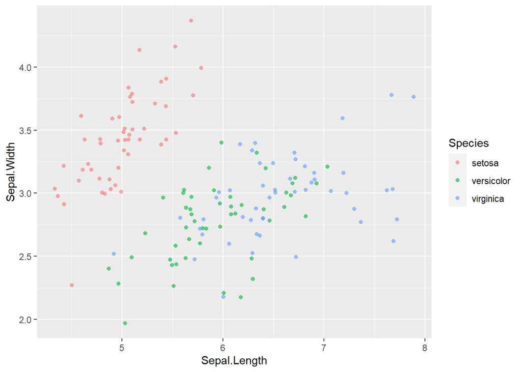

```r
data(iris)
ggplot(iris, aes(Sepal.Length, Sepal.Width,
                 col = Species)) +
  geom_jitter(alpha = 0.6)
```

The plot composes out of a combination of data and lots of non-data embellishments.

The text elements have their own unique names. We can access all the text in general and more specific items such as plot, legend and axis titles. All these items are arguments of the `theme()` function.

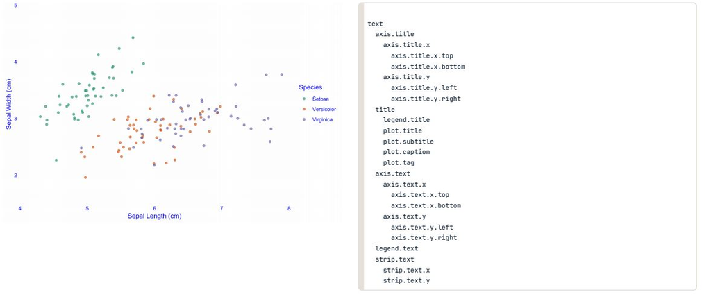

Within the `theme()` function we can manipulate size, color, alignment and angle of the text, in this case with `element_text` call. This is added like all other layers in **ggplot2** with a `+`.

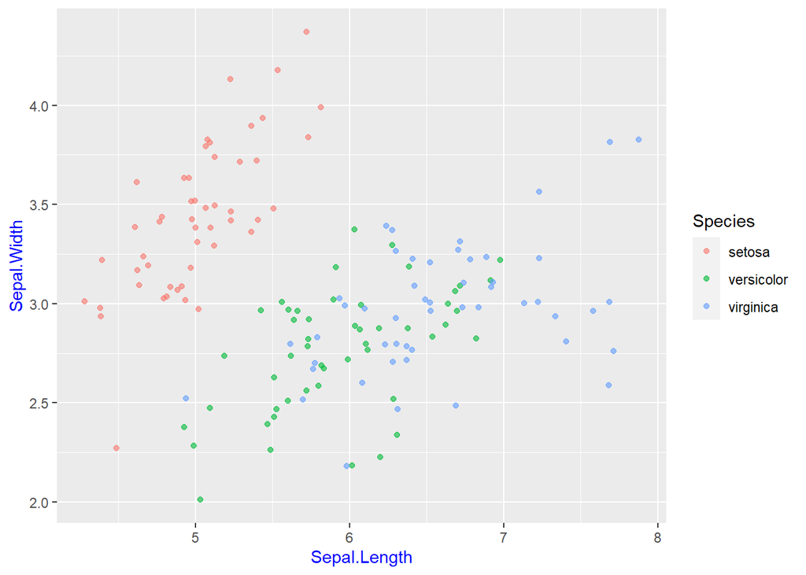

```r
ggplot(iris, aes(Sepal.Length, Sepal.Width,
                 col = Species)) +
  geom_jitter(alpha = 0.6) +
  theme(axis.title = element_text(color = "blue"))
```

Line elements include tick marks on the axes, the axis lines themselves and all grid lines, both major and minor. These are also arguments of `theme()` and can be modified by `element_line`.

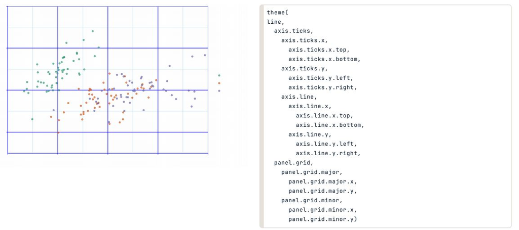

The remaining non-data ink on the plot are all rectangles of various sizes. Access rectangles using arguments in `theme()` and modify them using `element_rect.

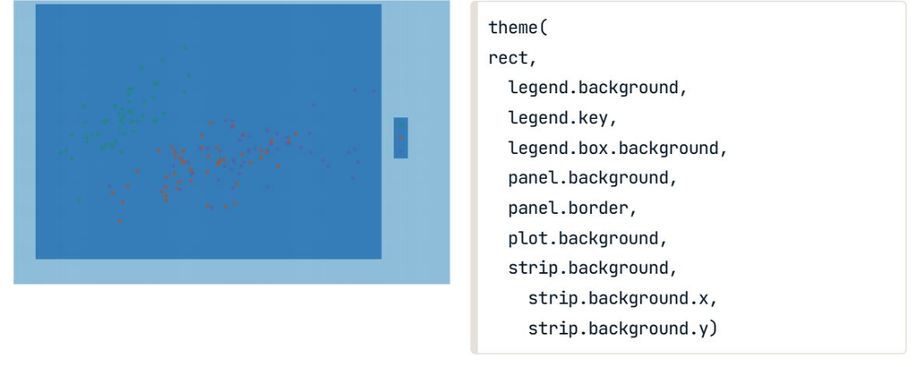

Although we have access to every item, we do not need to modify them individually. They inherent from each other in a hierarchy. All text elements inherit from text, so if text argument is changed, all downstream arguments would be affected. The same goes for lines and rectangles.

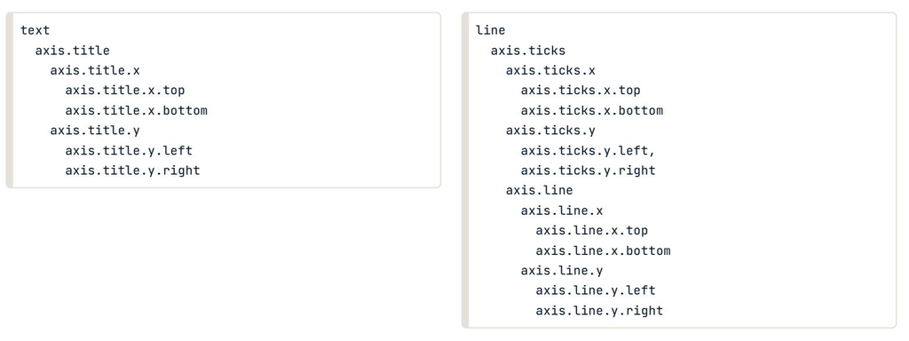

`element_blank()` is used to remove any item in the plot.

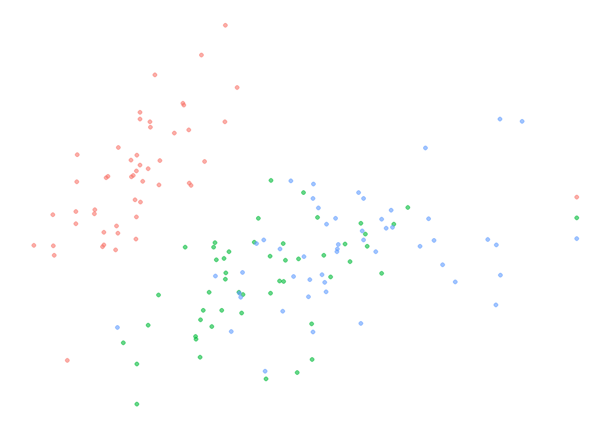

```r
ggplot(iris, aes(Sepal.Length, Sepal.Width,
                 col = Species)) +
  geom_jitter(alpha = 0.6) +
  theme(text = element_blank(),
        line = element_blank(),
        rect = element_blank())
```

All lines, texts and rectangles are set to blank, only the data left. Notice the legend keys themselves are part of the data.